# survival lecture 3

Steve Simon

May 5, 2018

Lecture 3. Planning and data management issues for survival data. Planning a study with a survival outcome requires you to specify both the number of patients and the duration of follow-up time. You’ll compute power for hypothetical studies and compare power across different research designs. Then you’ll review the data management needs of a survival study, with a special emphasis on the problems associated with date variables.

This file does not need any special libraries other than the ones listed below. Many of the data sets in this program use data from Hosmer, Lemeshow, and May. I made one minor change, however, which was to force all the variable names to lower case.

```r
library(broom)
library(dplyr)
```

```r
library(ggplot2)
library(magrittr)
library(survival)
library(tidyr)
```

## Power calculations

You can find a brief explanation of power in section 9.7 of Hosmer, Lemeshow, and May.

The total number of deaths to achieve a specified power, $\beta$, is

$m = \frac{(z_{\alpha/2}+z_\beta)^2}{\theta^2 \pi(1-\pi)}$

where $\pi$ is the proportion of deaths in the first group and $\theta$ is the log of the hazard ratio.

If you wish to use a two-sided test at an alpha level of 0.05, then

$z_{\alpha/2}=z_{0.025}=1.96$.

If you want to have at least 80% power, then

$z_\beta=z_{0.20}= 0.84$.

If you consider a doubling of the hazard rate as the minimum clinically important difference, then

$\theta=ln(2)=0.693$.

You expect to see half as many deaths in the treatment group compared to the control group, so

$\pi=0.33$

Then the number of deaths total, across both groups is

$m = \frac{(z_{\alpha/2}+z_\beta)^2}{\theta^2 \pi(1-\pi)} = \frac{(1.96+0.84)^2}{0.693^2 0.33(1-0.33)}= 73.5$.

Round this up to 75, with 25 deaths in the treatment group and 50 deaths in the control group.

```r
pi <- 1/3
theta <- log(2)
(qnorm(0.975)+qnorm(0.80))^2/(theta^2*pi*(1-pi))
```

```
## [1] 73.51387
```

Let’s round that up to 75, with 25 deaths in the first group and 50 deaths in the second group.

So, how many patients do you need to follow and for how long in order to get 75 deaths total?

You need to account for deaths that you never see

- because they occur after your study ends, or
- becuase of early dropouts.

You need to start making assumptions. In this example, assume that

- you follow the average patient for three years, and
- you will have a 20% early dropout rate,
- deaths follow an exponential distribution, and
- the baseline hazard rate is 0.4.

You can (and should) modify these assumptions to check sensitivity.

The survival function for the exponential distribution is

$S(t)=e^{-\lambda t}$

This produces two adjustment factors.

$e^{-1.2}=$ 0.3 in the first group and $e^{-2.4}=$ 0.09 in the second group.

Note that the probability of survival/death is not halved/doubled when you double the hazard rate.

Divide the number of deaths by 1 - the probability of survival and by 1 - the probability of early dropout to get the total number studied in each group.

$n_1 =$ 25 / ((1-0.2)(1-0.3)) = 44.7.

$n_2 =$ 50 / ((1-0.2)(1-0.09)) = 68.7.

To keep things simple, you might wish to use the larger of the two sample sizes in both groups.

## What does a hazard ratio of 2 mean in a clinical sense?

It is hard to get a practical understanding of how big a hazard ratio of 2 really is. You should draw a pair of survival curves to better understand what is going on.

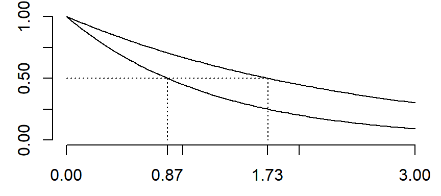

```r
lambda <- 0.4
t <- seq(0, 3, length=100)
s1 <- exp(-lambda*t)
s2 <- exp(-2*lambda*t)
par(mar=c(2.6, 2.7, 0.6, 0.6))
plot(t, s1, type="l", ylim=c(0, 1), axes=FALSE)
axis(side=1, at=c(0:3, round(log(2)/c(0.4, 0.8), 2)))
axis(side=2, at=(0:4)/4)
lines(t, s2)
segments(0, 0.5, log(2)/lambda, 0.5, lty="dotted")
segments(log(2)/lambda, 0.5, log(2)/lambda, 0, lty="dotted")
segments(0.5*log(2)/lambda, 0.5, 0.5*log(2)/lambda, 0, lty="dotted")
```

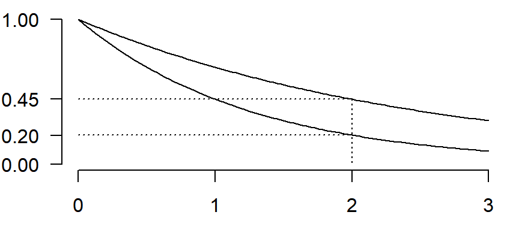

```r
par(las=1)
plot(t, s1, type="l", ylim=c(0, 1), axes=FALSE)
axis(side=1, at=0:3)
axis(side=2, at=c(0, 1, round(exp(-c(0.8, 1.6)), 2)))
lines(t, s2)
segments(0, exp(-0.8), 2, exp(-0.8), lty="dotted")
segments(0, exp(-1.6), 2, exp(-1.6), lty="dotted")
segments(2, exp(-0.8), 2, 0, lty="dotted")
```

## Simulation

You should consider running a computer simulation of your study instead of some of the formulas and adjustments shown above. Here’s an example of how this might be done.

Generate a random set of starting times for each patient.

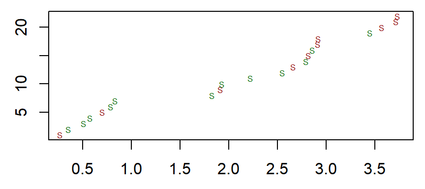

```r
par(mar=c(2.6, 2.6, 0.6, 0.6))
x <- 0.5
n_total <- 22
set.seed <- 222543
t <- rexp(n_total, 0.02*365)
co <- sample(c("darkred", "darkgreen"), n_total, replace=TRUE)
start_times <- cumsum(t)
plot(start_times, 1:n_total,
  type="n",
  xlab="Time", ylab="Patient")
text(start_times, 1:n_total, "S", col=co, adj=1, cex=x)
```

Generate a random death for each patient.

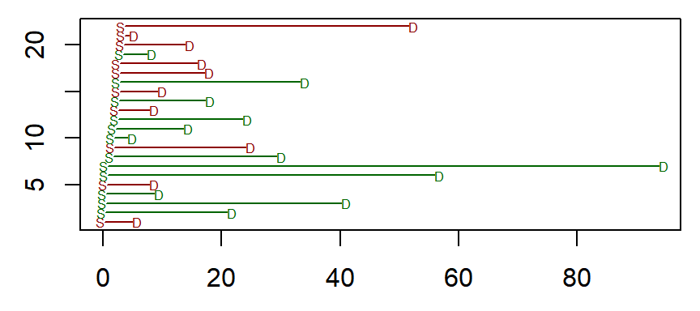

```r
par(mar=c(2.6, 2.6, 0.6, 0.6))
set.seed <- 222543
baseline_hazard <- 0.05
hazard_ratio <- 2
lambda <- ifelse(co=="darkgreen",
  baseline_hazard,
  baseline_hazard*hazard_ratio)
death_times <- start_times + rexp(n_total, lambda)
plot(start_times, 1:n_total,
  type="n", xlim=c(0, max(death_times)),
  xlab="Time", ylab="Patient")
text(start_times, 1:n_total, "S", col=co, adj=1, cex=x)
text(death_times, 1:n_total, "D", col=co, adj=0, cex=x)
segments(
  start_times, 1:n_total,
  death_times, 1:n_total,
  col=co)
```

Replace any deaths after study duration as censored.

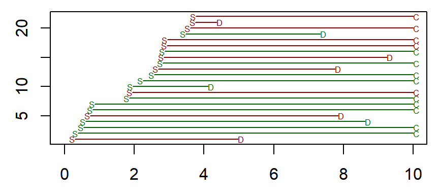

```r
par(mar=c(2.6, 2.6, 0.6, 0.6))
trial_duration <- 10
observed_times <- pmin(death_times, trial_duration)
marker <- ifelse(observed_times==death_times, "D", "C")
plot(start_times, 1:n_total,
  type="n", xlim=c(0, max(observed_times)),
  xlab="Time", ylab="Patient")
text(start_times, 1:n_total, "S", col=co, adj=1, cex=x)
text(observed_times, 1:n_total, marker, col=co, adj=0, cex=x)
segments(
  start_times, 1:n_total,
  observed_times, 1:n_total,
  col=co)
```

Simulate a random process for early dropouts.

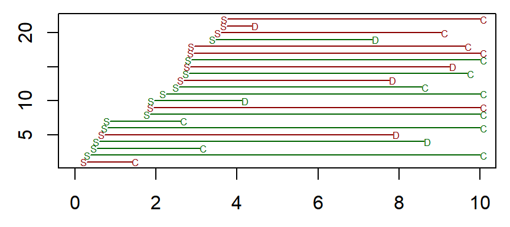

```r
par(mar=c(2.6, 2.6, 0.6, 0.6))
set.seed <- 222543
dropout_rate <- 0.06
dropout_times <- start_times + rexp(n_total, dropout_rate)
observed_times <- pmin(observed_times, dropout_times)
marker <- ifelse(observed_times==death_times, "D", "C")
plot(start_times, 1:n_total,
  type="n", xlim=c(0, max(observed_times)),
  xlab="Time", ylab="Patient")
text(start_times, 1:n_total, "S", col=co, adj=1, cex=x)
text(observed_times, 1:n_total, marker, col=co, adj=0,cex=x)
segments(
  start_times, 1:n_total,
  observed_times, 1:n_total,
  col=co)
```

Analyze these values. Repeat 1,000 times. The proportion of times that you reject the null hypothesis is an estimated power.

Vary some of the parameters in your study to see how sensitive your estimated power is to some of the underlying assumptions.

## Date manipulations in R

R stores dates as the number of days since January 1, 1970.

```r
baseline <- as.Date("1/1/1970", format="%m/%d/%Y")
print(baseline)
```

```
## [1] "1970-01-01"
```

```r
print(as.numeric(baseline))
```

```
## [1] 0
```

## Date differences

Start date: when therapy was initiated or when disease first appeared. This can be tricky.

Death date or event date: This will be missing values for any censored observation.

Date of last follow up.

Choose maximum of death/last followup. Set censor to 0 if death date is missing, 1 otherwise.

## Sample size justification

Hosmer, Lemeshow, and May discuss power calculations starting on page 340.

Also mention how number of events dominates power calculation and how you want 25 to 50 events in each group.

Save everything for possible later re-use.

```r
save.image("survival-lecture-3.RData")
```